# Impact of severe weather events on people and the economy of the United States

## Summary

Storms and other severe weather events can cause both public health and economic problems for communities and municipalities. Many severe events can result in fatalities, injuries, and property damage, and preventing such outcomes to the extent possible is a key concern.

This project involves exploring the U.S. National Oceanic and Atmospheric Administration’s (NOAA) storm database. This database tracks characteristics of major storms and weather events in the United States, including when and where they occur, as well as estimates of any fatalities, injuries, and property damage.

## Data

The data for this assignment come in the form of a comma-separated-value file compressed via the bzip2 algorithm to reduce its size. You can download the file from the course web site:

[Storm Data](https://d396qusza40orc.cloudfront.net/repdata%2Fdata%2FStormData.csv.bz2)

There is also some documentation of the database available. Here you will find how some of the variables are constructed/defined.

[National Weather Service Storm Data Documentation](https://d396qusza40orc.cloudfront.net/repdata%2Fpeer2_doc%2Fpd01016005curr.pdf)  
[National Climatic Data Center Storm Events FAQ](https://d396qusza40orc.cloudfront.net/repdata%2Fpeer2_doc%2FNCDC%20Storm%20Events-FAQ%20Page.pdf)  
The events in the database start in the year 1950 and end in November 2011. In the earlier years of the database there are generally fewer events recorded, most likely due to a lack of good records. More recent years should be considered more complete.

## Data Manipulation and Analysis

### Need to load the necessary packages. knirt, dplyr and ggplot2

```r
library(knitr)
library(dplyr)
```

```r
library(ggplot2)
library(gridExtra)
```

### Remove Date Warnings - Global Option

```r
knitr::opts_chunk$set(warning=FALSE)
```

### Down load the data from web site

The data is download from the provided link in wokring directory

```r
stormdataURL <- "https://d396qusza40orc.cloudfront.net/repdata%2Fdata%2FStormData.csv.bz2"
download.file(stormdataURL, destfile="./stormdataset.csv")
list.files("./")
```

```
## [1] "README.md"                         "Reproducible_Research_Proj2.html"
## [3] "Reproducible_Research_Proj2.Rmd"   "Reproducible_Research_Proj2.Rproj"
## [5] "Reproducible_Research_Proj2_cache" "Storm Events-FAQ Page.pdf"
## [7] "StormDataPrep.pdf"                 "stormdataset.csv"
```

```r
datestromdatadownload <- date()
datestromdatadownload
```

```
## [1] "Fri Nov 20 19:33:05 2020"
```

### Read the data set and inspect the data set

Data set is read and a Data Set is created with the raw data

```r
StormData <- read.csv("./stormdataset.csv", sep = ",", header = TRUE)
dim(StormData)
```

```
## [1] 902297     37
```

```r
head(StormData)
```

```
##   STATE__           BGN_DATE BGN_TIME TIME_ZONE COUNTY COUNTYNAME STATE  EVTYPE
## 1       1  4/18/1950 0:00:00     0130       CST     97     MOBILE    AL TORNADO
## 2       1  4/18/1950 0:00:00     0145       CST      3    BALDWIN    AL TORNADO
## 3       1  2/20/1951 0:00:00     1600       CST     57    FAYETTE    AL TORNADO
## 4       1   6/8/1951 0:00:00     0900       CST     89    MADISON    AL TORNADO
## 5       1 11/15/1951 0:00:00     1500       CST     43    CULLMAN    AL TORNADO
## 6       1 11/15/1951 0:00:00     2000       CST     77 LAUDERDALE    AL TORNADO
##   BGN_RANGE BGN_AZI BGN_LOCATI END_DATE END_TIME COUNTY_END COUNTYENDN
## 1         0                                               0         NA
## 2         0                                               0         NA
## 3         0                                               0         NA
## 4         0                                               0         NA
## 5         0                                               0         NA
## 6         0                                               0         NA
##   END_RANGE END_AZI END_LOCATI LENGTH WIDTH F MAG FATALITIES INJURIES PROPDMG
```

[output cut: 20 more lines]

```r
str(StormData)
```

```
## 'data.frame':    902297 obs. of  37 variables:
##  $ STATE__   : num  1 1 1 1 1 1 1 1 1 1 ...
##  $ BGN_DATE  : chr  "4/18/1950 0:00:00" "4/18/1950 0:00:00" "2/20/1951 0:00:00" "6/8/1951 0:00:00" ...
##  $ BGN_TIME  : chr  "0130" "0145" "1600" "0900" ...
##  $ TIME_ZONE : chr  "CST" "CST" "CST" "CST" ...
##  $ COUNTY    : num  97 3 57 89 43 77 9 123 125 57 ...
##  $ COUNTYNAME: chr  "MOBILE" "BALDWIN" "FAYETTE" "MADISON" ...
##  $ STATE     : chr  "AL" "AL" "AL" "AL" ...
##  $ EVTYPE    : chr  "TORNADO" "TORNADO" "TORNADO" "TORNADO" ...
##  $ BGN_RANGE : num  0 0 0 0 0 0 0 0 0 0 ...
##  $ BGN_AZI   : chr  "" "" "" "" ...
##  $ BGN_LOCATI: chr  "" "" "" "" ...
##  $ END_DATE  : chr  "" "" "" "" ...
##  $ END_TIME  : chr  "" "" "" "" ...
##  $ COUNTY_END: num  0 0 0 0 0 0 0 0 0 0 ...
```

[output cut: 23 more lines]

### Select Data that is between 1995 and 2011

Create a new variable called YEAR

```r
StormData$YEAR <- as.numeric(format(as.Date(StormData$BGN_DATE, format = "%m/%d/%Y %H:%M:%S"), "%Y"))
```

Select Data only between 1995 and 2011

```r
StormData <- StormData %>% filter(YEAR>1994, YEAR<2012)
str(StormData)
```

```
## 'data.frame':    681500 obs. of  38 variables:
##  $ STATE__   : num  1 1 1 1 1 1 1 1 1 1 ...
##  $ BGN_DATE  : chr  "1/6/1995 0:00:00" "1/22/1995 0:00:00" "2/6/1995 0:00:00" "2/11/1995 0:00:00" ...
##  $ BGN_TIME  : chr  "0300" "1800" "2100" "1300" ...
##  $ TIME_ZONE : chr  "CST" "CST" "CST" "CST" ...
##  $ COUNTY    : num  0 0 0 0 0 83 83 83 83 83 ...
##  $ COUNTYNAME: chr  "ALZ001 - 011 - 014 - 021 - 026" "ALZ001 - 021 - 024 - 027" "ALZ001>011 - 014 - 016>018 - 020" "ALZ001>029" ...
##  $ STATE     : chr  "AL" "AL" "AL" "AL" ...
##  $ EVTYPE    : chr  "FREEZING RAIN" "SNOW" "SNOW/ICE" "SNOW/ICE" ...
##  $ BGN_RANGE : num  0 0 0 0 0 0 4 0 12 11 ...
##  $ BGN_AZI   : chr  "" "" "" "" ...
##  $ BGN_LOCATI: chr  "" "" "" "North Alabama" ...
##  $ END_DATE  : chr  "" "1/23/1995 0:00:00" "2/8/1995 0:00:00" "2/12/1995 0:00:00" ...
##  $ END_TIME  : chr  "1000CST" "0800CST" "0500CST" "0400CST" ...
##  $ COUNTY_END: num  0 0 0 0 0 0 0 0 0 0 ...
```

[output cut: 24 more lines]

### Select variables of interest

- Weather Event, such as Tornadoes, Floods  
  + EVTYPE
- Personal and Health Impact  
  + FATALITIES  
  + INJURIES
- Economic Impact  
  + PROPDMG  
  + PROPDMGEXP  
  + CROPDMG  
  + CROPDMGEXP

```r
StormDataAnalysis <- subset(StormData, select=c(EVTYPE, FATALITIES, INJURIES, PROPDMG, PROPDMGEXP, CROPDMG, CROPDMGEXP))
head(StormDataAnalysis)
```

[output not shown]

```r
tail(StormDataAnalysis)
```

[output not shown]

### Four data sets will be created, one for each impact; Fatalities, Injuries, Property Damage, and Crop Damage.

Determine the total number of Injuries and fatalities per weather event by creating a separate data frames

```r
TotalFatalities <- StormDataAnalysis %>% group_by(EVTYPE) %>% summarise(Fatalities=sum(FATALITIES, na.rm = TRUE))
TotalFatalities <- TotalFatalities %>% arrange(desc(Fatalities))
TotalFatalities <- TotalFatalities[1:10, ]
dim(TotalFatalities)
```

```
## [1] 10  2
```

```r
head(TotalFatalities, n=10)
```

[output not shown]

```r
TopFatalityEvent <- TotalFatalities[1,1]
TopFatalityEvent
```

```
## # A tibble: 1 x 1
##   EVTYPE
##   <chr>
## 1 TORNADO
```

```r
TotalInjuries <- StormDataAnalysis %>% group_by(EVTYPE) %>% summarise(Injuries=sum(INJURIES, na.rm = TRUE))
TotalInjuries <- TotalInjuries %>% arrange(desc(Injuries))
TotalInjuries <- TotalInjuries[1:10, ]
dim(TotalInjuries)
```

```
## [1] 10  2
```

```r
head(TotalInjuries, n=10)
```

[output not shown]

```r
TopInjuryEvent <- TotalInjuries[1,1]
TopInjuryEvent
```

```
## # A tibble: 1 x 1
##   EVTYPE
##   <chr>
## 1 TORNADO
```

Determine the total economical impact for each weather event in Millions of Dollars and creating separate data frames for property damage and crop damage

```r
### Convert units from "letters" to dollars

StormDataAnalysis$PROPDMGEXP <- gsub(is.na(StormDataAnalysis$PROPDMGEXP), 0, StormDataAnalysis$PROPDMGEXP, ignore.case = TRUE) # NA's considered as 0 dollars
StormDataAnalysis$PROPDMGEXP <- gsub("[Mm]", 1e+06, StormDataAnalysis$PROPDMGEXP, ignore.case = TRUE)
StormDataAnalysis$PROPDMGEXP <- gsub("[Kk]", 1000, StormDataAnalysis$PROPDMGEXP, ignore.case = TRUE)
StormDataAnalysis$PROPDMGEXP <- gsub("[Bb]", 1e+09, StormDataAnalysis$PROPDMGEXP, ignore.case = TRUE)
StormDataAnalysis$PROPDMGEXP <- as.numeric(StormDataAnalysis$PROPDMGEXP)
StormDataAnalysis$CROPDMGEXP <- gsub(is.na(StormDataAnalysis$CROPDMGEXP), 0, StormDataAnalysis$CROPDMGEXP, ignore.case = TRUE) # NA's considered as 0 dollars
StormDataAnalysis$CROPDMGEXP <- gsub("[Mm]", 1e+06, StormDataAnalysis$CROPDMGEXP, ignore.case = TRUE)
StormDataAnalysis$CROPDMGEXP <- gsub("[Kk]", 1000, StormDataAnalysis$CROPDMGEXP, ignore.case = TRUE)
StormDataAnalysis$CROPDMGEXP <- gsub("[Bb]", 1e+09, StormDataAnalysis$CROPDMGEXP, ignore.case = TRUE)
StormDataAnalysis$CROPDMGEXP <- as.numeric(StormDataAnalysis$CROPDMGEXP)
## Create two new variable for the total damage in property and crops in millions of dollars
StormDataAnalysis <- mutate(StormDataAnalysis, TotalPropDMG=PROPDMG*PROPDMGEXP/1e+06, TotalCropDMG=CROPDMG*CROPDMGEXP/1e+06)

##Create two data frames for total damage per weather event
TotalPropDMG <- StormDataAnalysis %>% group_by(EVTYPE) %>% summarise(PropertyDamage=sum(TotalPropDMG, na.rm = TRUE))
TotalPropDMG <- TotalPropDMG %>% arrange(desc(PropertyDamage))
TotalPropDMG <- TotalPropDMG[1:10, ]
head(TotalPropDMG)
```

```
## # A tibble: 6 x 2
##   EVTYPE            PropertyDamage
##   <chr>                      <dbl>
## 1 FLOOD                    144658.
## 2 HURRICANE/TYPHOON         69306.
## 3 TORNADO                   56937.
## 4 STORM SURGE               43324.
## 5 FLASH FLOOD               16141.
## 6 HAIL                      15732.
```

```r
TopPropDMGEvent <- TotalPropDMG[1,1]
TopPropDMGEvent
```

```
## # A tibble: 1 x 1
##   EVTYPE
##   <chr>
## 1 FLOOD
```

```r
TotalCropDMG <- StormDataAnalysis %>% group_by(EVTYPE) %>% summarise(CropDamage=sum(TotalCropDMG, na.rm = TRUE))
TotalCropDMG <- TotalCropDMG %>% arrange(desc(CropDamage))
TotalCropDMG <- TotalCropDMG[1:10, ]
head(TotalCropDMG)
```

```
## # A tibble: 6 x 2
##   EVTYPE      CropDamage
##   <chr>            <dbl>
## 1 DROUGHT         13973.
## 2 FLOOD            5662.
## 3 RIVER FLOOD      5029.
## 4 ICE STORM        5022.
## 5 HAIL             3026.
## 6 HURRICANE        2742.
```

```r
TopCropDMGEvent <- TotalCropDMG[1,1]
TopCropDMGEvent
```

```
## # A tibble: 1 x 1
##   EVTYPE
##   <chr>
## 1 DROUGHT
```

## Results

### Plots

Bar plots will be used to identify the effect of extreme weather events on people (Fatalities and Injuries), and th economy (Property and Crop Damage).

First bar plots show the 10 largest impact on people by different extreme weather events

Second bar plots show the 10 largest impact on the property and crop by different extreme weather events.

[figure not shown]

```r
## Fatalities Bar Plot setup
FatalityPlot <- ggplot(data=TotalFatalities, aes(x=reorder(EVTYPE,-Fatalities), y=Fatalities, fill=EVTYPE)) + geom_bar(stat="identity", show.legend=F) + labs(title="Fatalities of Top 10 Events", x="Events", y="Total Fatalities") + theme(axis.text.x = element_text(angle = 45, hjust = 1))

## Injuries Bar Plot setup
InjuryPlot <- ggplot(data=TotalInjuries, aes(x=reorder(EVTYPE,-Injuries), y=Injuries, fill=EVTYPE)) + geom_bar(stat="identity", show.legend=F) + labs(title="Injuries of Top 10 Events", x="Events", y="Total Fatalities") + theme(axis.text.x = element_text(angle = 45, hjust = 1))

## Fatalities and Injuries Graph
grid.arrange(FatalityPlot, InjuryPlot, ncol = 2)
```

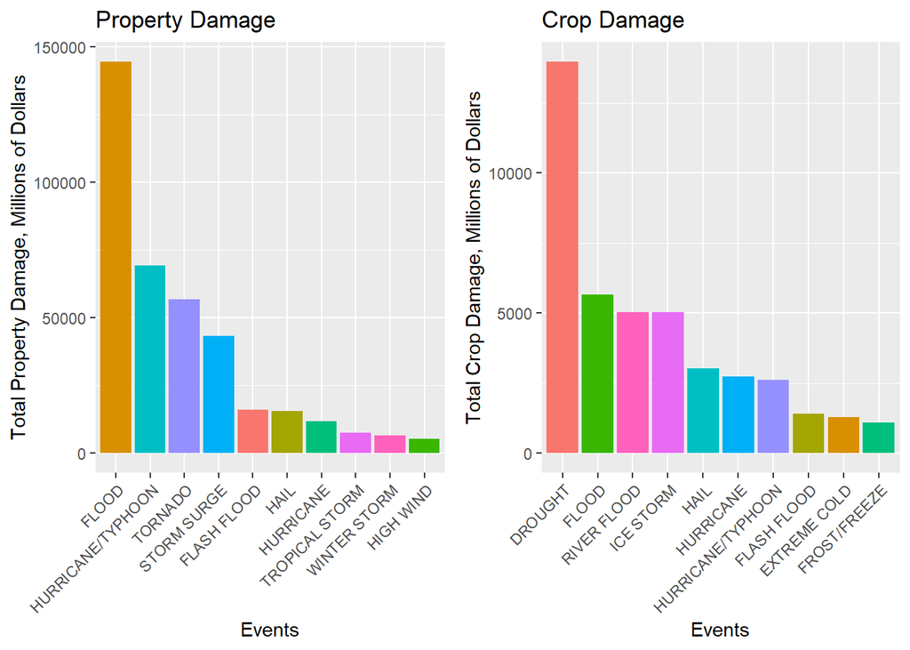

```r
## Property Damage Plot setup
PropDMGPlot <- ggplot(data=TotalPropDMG, aes(x=reorder(EVTYPE,-PropertyDamage), y=PropertyDamage, fill=EVTYPE)) + geom_bar(stat="identity", show.legend=F) + labs(title="Property Damage", x="Events", y="Total Property Damage, Millions of Dollars") + theme(axis.text.x = element_text(angle = 45, hjust = 1))

## Crop Damage Plot setup
CropDMGPlot <- ggplot(data=TotalCropDMG, aes(x=reorder(EVTYPE,-CropDamage), y=CropDamage, fill=EVTYPE))+ geom_bar(stat="identity", show.legend=F) + labs(title="Crop Damage", x="Events", y="Total Crop Damage, Millions of Dollars") + theme(axis.text.x = element_text(angle = 45, hjust = 1))

## Property and Crop Damage Graph
grid.arrange(PropDMGPlot, CropDMGPlot, ncol = 2)
```

### Summary of the results

After evaluating the bar plots and analyzing the data we can conclude the following:  
* The Weather Event that caused more fatalities between 1995 and 2011 is: **Tornado**  
* The Weather Event that caused more Injuries between 1995 and 2011 is: **Tornado**  
* The Weather Event that caused more Property Loses between 1995 and 2011 is: **Flood**  
* The Weather Event that caused more Crop Loses between 1995 and 2011 is: **Drought**